# Simple Regression & The General Linear Model

# Overview

- Today we will briefly review univariate regression and then will discuss how to summarize and visualize uncertainty in regression models using a variety of plotting methods. We will then touch on how to estimate regression coefficients using matrix algebra. Lastly, we will introduce the General Linear Model and demonstrate how GLM can be used to understand all of the statistical tests we have learned so far (*t*-tests, ANOVA, correlations, regressions) within one (beautiful!) unifying framework.

## Dataset

- We’re going to work with a made-up dataset about the relationship between personality and health. Let’s pretend we’ve collected data from 60 people (30 men and 30 women) on their self-reported conscientiousness (using the [Big Five Inventory](https://www.ocf.berkeley.edu/~johnlab/bfi.htm)) and their self-rated physical health.
- The data is stored in a dataframe called `health` and has been pre-loaded for you. You can get a glimpse of the data below.

##### Code

```r
glimpse(health)
```

##### Output

```
## Rows: 60
## Columns: 4
## $ pid       <int> 1, 2, 3, 4, 5, 6, 7, 8, 9, 10, 11, 12, 13, 14, 15, 16, 17, …
## $ gender    <chr> "male", "male", "male", "male", "male", "male", "male", "ma…
## $ consc     <dbl> 2.659688, 5.022069, 3.846887, 1.734497, 3.452961, 4.005985,…
## $ sr_health <dbl> 1.909508, 4.493539, 3.403894, 2.045359, 4.210038, 5.111872,…
```

# Visualizing uncertainty in regression

- Before we discuss how to visualize uncertainty in regression, let’s quickly review how to estimate a regression model in R.
- One way to estimate linear regression models involves using the `lm()` function, which is part of the pre-loaded {stats} library. There are basically two ingredients we pass to the `lm()` function:
  1. **The formula:** Specify your regression formula in the general form `y ~ x`.
  2. **The data:** the dataframe that contains the variables in the formula.
- Recall from the previous lab how we wrote out our model, specifying self-rated health as a function of conscientiousness

$$Y_i = b_0 + b_1X_i + e_i$$

$$sr\_health_i = b_0 + b_1consc_i + e_i$$

- Fill in the blanks below to specify and estimate the regression model using `lm()`.

[interactive chart not shown]

- Here are our model coefficients…

Results of Regressing Self-Reported Health on Conscientiousness

| coefficient | b | SE | t | p |
| --- | --- | --- | --- | --- |
| (Intercept) | 1.66 | 0.36 | 4.64 | < .001 |
| consc | 0.49 | 0.12 | 4.13 | < .001 |

##### Question

> **What do the intercept and slope mean? What do the *t*-values tell us?**

##### Answer

> The intercept is the expected value for self-rated health when conscientiousness is 0.

> The slope is the magnitude of the relationship between conscientiousness and self-rated health: for every 1-unit increase in conscientiousness, we expect a 0.49-unit increase in self-rated health.

> *t*-values are from a one-sample *t*-test assessing whether the slope and intercept are significantly different from 0. The *t*-values represent the ratio of signal to noise (i.e. each *b* divided by its standard error).

## Confidence intervals

- Our `b's` (intercept and slope) are *estimates* from our sample of true population parameters ($\beta$’s). Remember that whenever we calculate an estimate of something, we should also determine how precise our estimate is. This is where standard errors and confidence intervals come in.
- Recall the formula for calculating confidence intervals:

$$CI_b = b \pm critical\_value * SE_b$$

- In Minihack 2 you will get some practice using this formula to calculate confidence intervals around regression coefficients. For now, we will use a much easier method: `stats::confint()`. This function takes in a fitted model object as the first argument. By default it will give you 95% CI’s.

##### Code

```r
confint(model)
```

##### Output

```
##                 2.5 %    97.5 %
## (Intercept) 0.9422515 2.3716950
## consc       0.2526050 0.7282069
```

##### Question

> **What does the 95% CI for the slope of conscientiousness mean in plain English?**

##### Answer

> If we were to repeat this experiment over and over again, sampling from the same population, 95% of the time the slope we calculate would be between 0.25 and 0.73 (i.e. in 19 out of every 20 experiments we’d get a slope in this interval).  
> More generally it means that if we carried out random sampling from the population a large number of times, and calculated the 95% CI each time around our coefficients (intercept and slope), then 95% of those intervals can be expected to contain the population parameters.  
> In other words, we have good reason to believe the true population parameters ($\beta_0$ and $\beta_1$) fall in this interval because 95% of the time such intervals contain the true population parameters.

## Confidence bands

- In addition to estimating precision around our coefficients, we can also estimate precision (using standard errors) around each predicted value, $\hat{Y_i}$. These standard errors are generated by `broom::augment()` (and are labeled `.se.fit`).

##### Code

```r
model %>% # start with our model object
  augment() %>% # from broom package; gives us fitted values, residuals, etc.
  select(sr_health, .fitted, .se.fit) # select relevant variables
```

##### Output

| sr_health | .fitted | .se.fit |
| --- | --- | --- |
| 1.909508 | 2.961300 | 0.1164587 |
| 4.493539 | 4.119826 | 0.2825073 |
| 3.403894 | 3.543509 | 0.1648175 |
| 2.045359 | 2.507581 | 0.1747697 |
| 4.210038 | 3.350326 | 0.1350601 |
| 5.111872 | 3.621532 | 0.1789150 |
| 3.089556 | 3.038562 | 0.1143604 |
| 4.575580 | 3.570843 | 0.1696499 |
| 3.902935 | 3.178485 | 0.1182560 |
| 2.637214 | 3.147345 | 0.1165505 |

[output cut: 50 more lines]

- If we were to string all of this information together, it would generate a confidence **band** around our regression line. You can generate a confidence band when creating a scatter plot of your data by adding the following layer to your plot: `geom_smooth(method = "lm")`.
- Fill in the blanks in the code below to generate a scatter plot with a linear regression line and 95% confidence band.

[interactive chart not shown]

- The animation below is an example of a [“Hypothetical Outcomes Plot”](https://github.com/wilkelab/ungeviz) (HOP) that visually demonstrates what this 95% CI band represents. In essence, this plot shows what the regression line could look like if we were to repeat our experiment over and over (sampling from the same population each time).

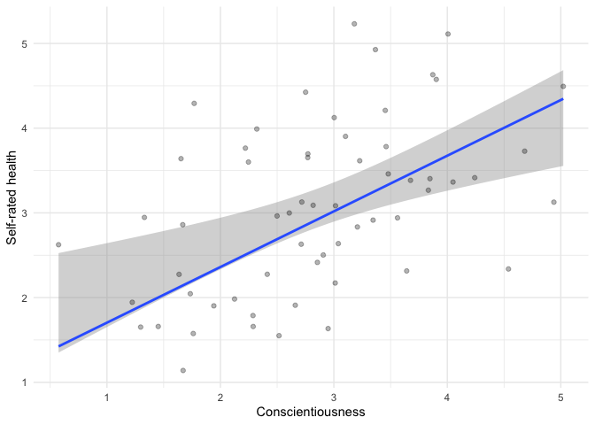

## Prediction

- A regression line, by definition, corresponds to the line that gives the *mean* value of `Y` corresponding to each possible value of `X`, i.e. `E(Y|X)`.
- In addition, we can also predict an individual’s score ($Y_i$) for any value of `X`. From our regression model, we have the following equation that mathematically represents the relationship between conscientiousness and self-rated health:

$$\hat{health}_{i} = 1.6569733 + 0.4904059 * consc_{i}$$

- For example, if we know someone’s conscientiousness score is `3.5`, we can predict their score for self-rated health according to our model:

$$\hat{health} = 1.6569733 + 0.4904059*3.5 = 3.374$$

- The `predict()` function gives us a straightforward way to get the predicted `Y` values from all the `X` values in our dataset.

##### Code

```r
predict(model)
```

##### Output

```
##        1        2        3        4        5        6        7        8
## 2.961300 4.119826 3.543509 2.507581 3.350326 3.621532 3.038562 3.570843
##        9       10       11       12       13       14       15       16
## 3.178485 3.147345 2.758911 3.403290 2.987058 3.015841 3.216697 3.135321
##       17       18       19       20       21       22       23       24
## 3.056917 3.006047 3.015321 3.297619 2.458993 2.840238 3.082434 2.292952
##       25       26       27       28       29       30       31       32
## 3.103269 3.133964 2.989617 3.354057 2.882657 3.952820 2.891139 3.307783
##       33       34       35       36       37       38       39       40
## 2.745710 3.555768 3.643154 2.474954 2.778601 2.520440 2.935472 2.524356
##       41       42       43       44       45       46       47       48
## 2.467469 3.442900 4.079152 2.368996 3.882772 2.256636 3.239823 2.609330
##       49       50       51       52       53       54       55       56
## 2.309207 3.229900 2.795072 2.476516 3.459384 3.363102 3.536529 1.938202
##       57       58       59       60
## 2.698847 3.737070 3.129544 2.779391
```

- The predictions we just generated should look familiar, as we already have gotten this information from `broom::augment()`.

##### Code

```r
augment(model)$.fitted
```

##### Output

```
##  [1] 2.961300 4.119826 3.543509 2.507581 3.350326 3.621532 3.038562 3.570843
##  [9] 3.178485 3.147345 2.758911 3.403290 2.987058 3.015841 3.216697 3.135321
## [17] 3.056917 3.006047 3.015321 3.297619 2.458993 2.840238 3.082434 2.292952
## [25] 3.103269 3.133964 2.989617 3.354057 2.882657 3.952820 2.891139 3.307783
## [33] 2.745710 3.555768 3.643154 2.474954 2.778601 2.520440 2.935472 2.524356
## [41] 2.467469 3.442900 4.079152 2.368996 3.882772 2.256636 3.239823 2.609330
## [49] 2.309207 3.229900 2.795072 2.476516 3.459384 3.363102 3.536529 1.938202
## [57] 2.698847 3.737070 3.129544 2.779391
```

### Prediction bands

- We can use this information to create and visualize “prediction bands”. First we will generate our predicted values (i.e. fitted values) along with a “prediction interval” (lower and upper bound) for each of these values.

##### Code

```r
predicted <- predict(model, interval = "prediction")
predicted
```

##### Output

```
##         fit        lwr      upr
## 1  2.961300 1.17371888 4.748882
## 2  4.119826 2.25947787 5.980173
## 3  3.543509 1.74074780 5.346271
## 4  2.507581 0.70106755 4.314095
## 5  3.350326 1.55750837 5.143143
## 6  3.621532 1.81339348 5.429671
## 7  3.038562 1.25152397 4.825601
## 8  3.570843 1.76628606 5.375400
## 9  3.178485 1.39043087 4.966539
## 10 3.147345 1.35973942 4.934950
## 11 2.758911 0.96619235 4.551629
## 12 3.403290 1.60822745 5.198353
## 13 2.987058 1.19974524 4.774372
## 14 3.015841 1.22872479 4.802958
```

[output cut: 46 more lines]

- Next we’ll bind these predicted values (and their prediction intervals) to our original dataset, so we can create a plot from a single data frame.

##### Code

```r
pred_plot_data <- cbind(health, predicted)
pred_plot_data
```

##### Output

|  | pid | gender | consc | sr_health | fit | lwr | upr |
| --- | --- | --- | --- | --- | --- | --- | --- |
| 1 | 1 | male | 2.6596884 | 1.909508 | 2.961300 | 1.17371888 | 4.748882 |
| 2 | 2 | male | 5.0220685 | 4.493539 | 4.119826 | 2.25947787 | 5.980173 |
| 3 | 3 | male | 3.8468867 | 3.403894 | 3.543509 | 1.74074780 | 5.346271 |
| 4 | 4 | male | 1.7344974 | 2.045359 | 2.507581 | 0.70106755 | 4.314095 |
| 5 | 5 | male | 3.4529606 | 4.210038 | 3.350326 | 1.55750837 | 5.143143 |
| 6 | 6 | male | 4.0059852 | 5.111872 | 3.621532 | 1.81339348 | 5.429671 |
| 7 | 7 | male | 2.8172358 | 3.089556 | 3.038562 | 1.25152397 | 4.825601 |
| 8 | 8 | male | 3.9026234 | 4.575580 | 3.570843 | 1.76628606 | 5.375400 |
| 9 | 9 | male | 3.1025556 | 3.902935 | 3.178485 | 1.39043087 | 4.966539 |
| 10 | 10 | male | 3.0390568 | 2.637214 | 3.147345 | 1.35973942 | 4.934950 |

[output cut: 50 more lines]

- And finally, we’ll plot a prediction band on top of the data by adding a `geom_ribbon()`. This prediction band represents, for every value of `X`, the interval that represents the range of values that is likely to contain the value of a single new individual observation. Unlike confidence intervals, prediction intervals predict the spread for individual observations rather than the mean.
- Fill in the blanks in the code to create a plot of the prediction band for our linear regression model. Pay special attention to `lwr` and `upr` within `pred_plot_data` above. How will you incorporate these variables into the plot?

[interactive chart not shown]

##### Question

> **Why is the prediction band wider than the confidence band around our regression line?**

##### Answer

> Because there is greater variation in predicting an individual value rather than a collection of individual values (i.e., the mean) the prediction band is wider.

### Out-of-sample prediction

- Remember, we can plug *any* `X` value (i.e. conscientiousness score) into our regression equation and predict the corresponding `Y` value (i.e. self-rated health score). And when I say *any* `X` value, I mean that it doesn’t have to be an actual observation from our sample. We can also predict out-of-sample!
- To illustrate this, we’ll use a data frame that has new `X` values (conscientiousness scores). Let’s pretend that we collected this data from a completely new sample of people.

##### Code

```r
# read in new data
consc_data_new <- import("https://raw.githubusercontent.com/uopsych/psy612/master/labs/lab-3/data/consc_new.csv")

# let's view it
consc_data_new
```

##### Output

|  | consc |
| --- | --- |
| 1 | 4.1200772 |
| 2 | 3.9954688 |
| 3 | 3.1994967 |
| 4 | 2.0254451 |
| 5 | 2.1551067 |
| 6 | 2.1834635 |
| 7 | 1.7511843 |
| 8 | 3.1572808 |
| 9 | 3.3280520 |
| 10 | 1.5461296 |

[output cut: 10 more lines]

- Now we can predict `Y` values for these out-of-sample `X` values based on the coefficients from our regression model. We just have to tell the `predict()` function what our `newdata` is.
- Fill in the blanks in the code below to make predictions about self-rated health values based on brand new, never-before seen conscientiousness scores.

[interactive chart not shown]

## Other visualization tools

- `sjPlot::plot_model()`

##### Code

```r
plot_model(model = model,    # name of model object
           type = "pred",    # show predicted values (i.e. regression line)
           show.data = TRUE, # include data points on plot
           jitter = TRUE)    # add small amount of random variation to  to prevent overlap
```

##### Output

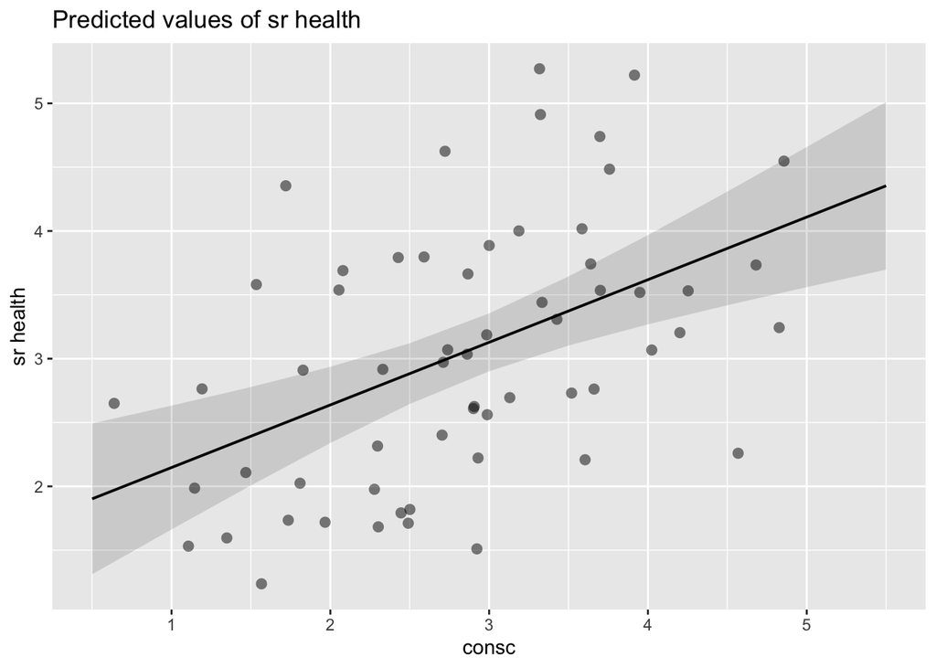

- `ggpubr::ggscatter()`

##### Code

```r
ggscatter(data = health,              # name of data.frame
          x = "consc",                # IV (must be quoted)
          y = "sr_health",            # DV (must be quoted)
          add = "reg.line",           # add regression line
          xlab = "Conscientiousness", # x-axis label
          ylab = "Self-rated health", # y-axis label
          conf.int = TRUE,            # show 95% confidence band around regression line
          cor.coef = TRUE)            # display correlation coefficient and p-value
```

##### Output

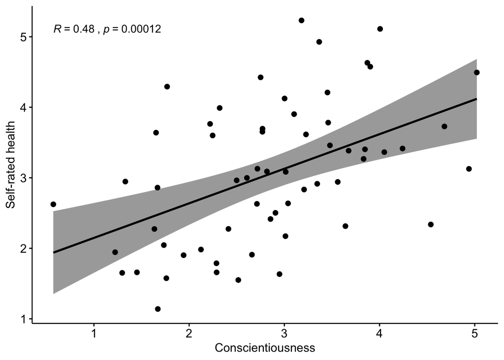

# Regression with matrix algebra

## Review

- Consider our regression equation in it’s general form:

$$\mathbf{y} = b_0 + b_1\mathbf{x} + e$$

- Recall that `y` is a vector of values, which can be represented as an $n\times1$ matrix, $\mathbf{Y}$. Similarly, `x` can be represented as an $n\times1$ matrix, $\mathbf{X}$.
- If we augment the matrix $\mathbf{X}$ to be an $n\times2$ matrix, in which the first column is filled with `1`’s, we can simplify our regression equation (one property of the residuals is that the the average residual is 0, so we can remove `e` from the equation as well):

$$\mathbf{Y} = \mathbf{XB}$$

- Note: $\mathbf{B}$ is a $2 \times 1$ matrix containing our estimates of the intercept and slope.

## Example

- Let’s illustrate how this works by running our regression analysis (self-rated health ~ conscientiousness) using matrix algebra.
- Create the **`X`** matrix

##### Code

```r
x_mat <- health %>% # start with the original data frame
  mutate(ones = rep(1, nrow(.))) %>% # create a column of 1's to represent the intercept
  select(ones, consc) %>% # select only the column of 1's and X variable
  as.matrix() %>%  # coerce to a matrix
  unname() # get rid of dimnames

print(x_mat)
```

##### Output

```
##       [,1]      [,2]
##  [1,]    1 2.6596884
##  [2,]    1 5.0220685
##  [3,]    1 3.8468867
##  [4,]    1 1.7344974
##  [5,]    1 3.4529606
##  [6,]    1 4.0059852
##  [7,]    1 2.8172358
##  [8,]    1 3.9026234
##  [9,]    1 3.1025556
## [10,]    1 3.0390568
## [11,]    1 2.2469903
## [12,]    1 3.5609621
## [13,]    1 2.7122125
## [14,]    1 2.7709048
```

[output cut: 46 more lines]

- Create the **`Y`** matrix

##### Code

```r
y_mat <- health %>% # start with the original data frame
  select(sr_health) %>% # select just the Y variable
  as.matrix() %>% # coerce to a matrix
  unname() # get rid of dimnames

print(y_mat)
```

##### Output

```
##           [,1]
##  [1,] 1.909508
##  [2,] 4.493539
##  [3,] 3.403894
##  [4,] 2.045359
##  [5,] 4.210038
##  [6,] 5.111872
##  [7,] 3.089556
##  [8,] 4.575580
##  [9,] 3.902935
## [10,] 2.637214
## [11,] 3.600213
## [12,] 2.941156
## [13,] 2.630240
## [14,] 3.696171
```

[output cut: 46 more lines]

- Recall the matrix algebra formula to solve for the **`B`** matrix

$$\mathbf{B} = (\mathbf{X'X})^{-1} \mathbf{X'Y}$$

- Fill in the blanks in the code below to solve for the model coefficients. Check out the hint if you can’t think of which functions to use! And see [here](https://uopsych.github.io/psy611/labs/lab-3.html) for a refresher on matrix algebra.

[interactive chart not shown]

# The General Linear Model

- We just saw that regression works “under the hood” by solving a matrix algebra equation to get the intercept and slope of the regression line. This matrix algebra equation works for *any* type of data we have. This should clue us into the idea that there is some fundamental process going on behind the scenes of all of our models…
- The **general linear model (GLM)** is a family of models that assume the relationship between your DV and IV(s) is linear and additive, and that your outcome is normally distributed. In its simplest form, we can think of the general linear model as:

$$Data = Model + Error$$

- This provides a unifying framework for all of the statistical tests we have learned (or at least touched on) so far: *t*-tests, correlations, ANOVA, and linear regression. All of these tests are really doing the same math at the end of the day.
- To illustrate this, we’ll turn back to an [example from PSY611](https://uopsych.github.io/psy611/labs/lab-8.html#the_data). The data are from Fox and Guyer’s (1978) anonymity and cooperation study. The data are included in the `{carData}` package, and you can see information about the data set using `?Guyer`. Twenty groups of four participants each played 30 trials of the the prisoner’s dilemma game. The number of cooperative choices (`cooperation`) made by each group were scored out of 120 (i.e., cooperative choices made by 4 participants over 30 trials). The groups either made decisions publicly or privately (`condition`).
- You can load in the data with the following code:

```r
guyer <- carData::Guyer
```

- Let’s look at the first few rows…

##### Code

```r
head(guyer)
```

##### Output

|  | cooperation | condition | sex |
| --- | --- | --- | --- |
| 1 | 49 | public | male |
| 2 | 64 | public | male |
| 3 | 37 | public | male |
| 4 | 52 | public | male |
| 5 | 68 | public | male |
| 6 | 54 | public | female |

- …and the structure of the data

##### Code

```r
str(guyer)
```

##### Output

```
## 'data.frame':    20 obs. of  3 variables:
##  $ cooperation: num  49 64 37 52 68 54 61 79 64 29 ...
##  $ condition  : Factor w/ 2 levels "anonymous","public": 2 2 2 2 2 2 2 2 2 2 ...
##  $ sex        : Factor w/ 2 levels "female","male": 2 2 2 2 2 1 1 1 1 1 ...
```

- Convert the `condition` variable to `0's` and `1's`. We will talk more about dummy coding in a future lab.

##### Code

```r
guyer <-  guyer %>%
  mutate(condition = case_when(condition == "public" ~ 0,
                               condition == "anonymous" ~ 1))

guyer
```

##### Output

| cooperation | condition | sex |
| --- | --- | --- |
| 49 | 0 | male |
| 64 | 0 | male |
| 37 | 0 | male |
| 52 | 0 | male |
| 68 | 0 | male |
| 54 | 0 | female |
| 61 | 0 | female |
| 79 | 0 | female |
| 64 | 0 | female |
| 29 | 0 | female |

[output cut: 10 more lines]

## *t*-test

- Fill in the blanks in the code below to run an independent samples t-test testing the difference in mean number of cooperative choices made in the `public` and `anonymous` conditions. Assume the homogeneity of variance assumption has been met.

[interactive chart not shown]

##### Question

> **What is the 95% CI around?**

##### Answer

> The difference in mean cooperation scores for the `public` vs. `anonymous` conditions.

## Correlation

- Fill in the blanks in the code below to run a correlation test between `cooperation` and `condition`.

[interactive chart not shown]

##### Question

> **What is the 95% CI around this time?**

##### Answer

> The correlation coefficient between `cooperation` and `condition`

## ANOVA

- Fill in the blanks in the code below to run an ANOVA testing the difference in mean number of cooperative choices made in the `public` and `anonymous` conditions.

[interactive chart not shown]

##### Question

> **What is the relationship between the *F* statistic from this ANOVA and the *t* statistic from our previous two tests?**

##### Answer

> *t* is the square root of *F*.

## Regression

- Fill in the blanks in the code below to run a linear regression model where `cooperation` varies as a function of `condition`.

[interactive chart not shown]

##### Question

> **What does the intercept represent? The slope?**

##### Answer

> The intercept is the mean cooperation score for the condition that was coded as 0 (i.e. `public`). The slope is the difference in means between the two conditions.
- Note: The *p* values from all 4 models you just ran are exactly the same! Why? Because all 4 tests are all based on the same underlying general linear model!

# Minihacks

## Minihack 1: Matrix algebra

- Continuing with the `guyer` dataset example, use matrix algebra to manually calculate the intercept and slope for the regression equation (`cooperation` ~ `condition`).
- Hint: To find the inverse of a matrix, use the `solve()` function. Refer back to the [lab on matrix algebra](https://uopsych.github.io/psy611/labs/lab-3.html) from PSY611 for a refresher on other matrix operations if needed.
1. Create the matrix $\mathbf{X}$ & vector $\mathbf{Y}$

[interactive chart not shown]

2. Solve for the model coefficients using $\mathbf{B = (X'X)}^{-1}\mathbf{X'Y}$

[interactive chart not shown]

3. Confirm your results using the `lm()` function in R.

[interactive chart not shown]

## Minihack 2: Confidence intervals

- For this minihack, we will refer back to the example about conscientiousness and health. We used `confint()` to calculate the 95% CI for our regression coefficients. Your job is start with the model output, stored as a list object, and extract the relevant pieces of information to calculate the 95% CI around the intercept and slope.
1. Calculate confidence intervals “by hand”. (Hint: Use `qt()` to draw from a *t* distribution)
- Here’s the model output again for reference.

```r
model <- lm(sr_health ~ consc, data = health)
model_summary <- summary(model)
model_summary
```

```
##
## Call:
## lm(formula = sr_health ~ consc, data = health)
##
## Residuals:
##     Min      1Q  Median      3Q     Max
## -1.5450 -0.6414 -0.1623  0.6817  2.0154
##
## Coefficients:
##             Estimate Std. Error t value  Pr(>|t|)
## (Intercept)   1.6570     0.3571   4.641 0.0000203 ***
## consc         0.4904     0.1188   4.128  0.000119 ***
## ---
## Signif. codes:  0 '***' 0.001 '**' 0.01 '*' 0.05 '.' 0.1 ' ' 1
##
## Residual standard error: 0.8854 on 58 degrees of freedom
## Multiple R-squared:  0.2271, Adjusted R-squared:  0.2138
## F-statistic: 17.04 on 1 and 58 DF,  p-value: 0.0001186
```

[interactive chart not shown]

2. Verify that your answer corresponds to the result from `confint()`.

[interactive chart not shown]